# Risk Factor Analysis

## Outcome Variable

**Outcome Variable:** ever_stunted

## Predictor Variables

**Intervention Variable:** hdlvry

**Adjustment Set:**

unadjusted

## Stratifying Variables

The analysis was stratified on these variable(s):

- agecat
- studyid
- country

## Data Summary

| agecat | studyid | country | hdlvry | ever_stunted | n_cell | n |
| --- | --- | --- | --- | --- | --- | --- |
| 0-6 months | ki1000108-CMC-V-BCS-2002 | INDIA | 0 | 0 | 284 | 365 |
| 0-6 months | ki1000108-CMC-V-BCS-2002 | INDIA | 0 | 1 | 74 | 365 |
| 0-6 months | ki1000108-CMC-V-BCS-2002 | INDIA | 1 | 0 | 5 | 365 |
| 0-6 months | ki1000108-CMC-V-BCS-2002 | INDIA | 1 | 1 | 2 | 365 |
| 0-6 months | ki1000108-IRC | INDIA | 0 | 0 | 353 | 410 |
| 0-6 months | ki1000108-IRC | INDIA | 0 | 1 | 49 | 410 |
| 0-6 months | ki1000108-IRC | INDIA | 1 | 0 | 7 | 410 |
| 0-6 months | ki1000108-IRC | INDIA | 1 | 1 | 1 | 410 |
| 0-6 months | ki1000109-EE | PAKISTAN | 0 | 0 | 162 | 377 |
| 0-6 months | ki1000109-EE | PAKISTAN | 0 | 1 | 91 | 377 |
| 0-6 months | ki1000109-EE | PAKISTAN | 1 | 0 | 85 | 377 |
| 0-6 months | ki1000109-EE | PAKISTAN | 1 | 1 | 39 | 377 |
| 0-6 months | ki1000304b-SAS-CompFeed | INDIA | 0 | 0 | 113 | 1248 |
| 0-6 months | ki1000304b-SAS-CompFeed | INDIA | 0 | 1 | 53 | 1248 |
| 0-6 months | ki1000304b-SAS-CompFeed | INDIA | 1 | 0 | 774 | 1248 |
| 0-6 months | ki1000304b-SAS-CompFeed | INDIA | 1 | 1 | 308 | 1248 |
| 0-6 months | ki1000304b-SAS-FoodSuppl | INDIA | 0 | 0 | 58 | 416 |
| 0-6 months | ki1000304b-SAS-FoodSuppl | INDIA | 0 | 1 | 23 | 416 |
| 0-6 months | ki1000304b-SAS-FoodSuppl | INDIA | 1 | 0 | 199 | 416 |
| 0-6 months | ki1000304b-SAS-FoodSuppl | INDIA | 1 | 1 | 136 | 416 |
| 0-6 months | ki1017093b-PROVIDE | BANGLADESH | 0 | 0 | 469 | 700 |
| 0-6 months | ki1017093b-PROVIDE | BANGLADESH | 0 | 1 | 50 | 700 |
| 0-6 months | ki1017093b-PROVIDE | BANGLADESH | 1 | 0 | 165 | 700 |
| 0-6 months | ki1017093b-PROVIDE | BANGLADESH | 1 | 1 | 16 | 700 |
| 0-6 months | ki1017093c-NIH-Crypto | BANGLADESH | 0 | 0 | 514 | 758 |
| 0-6 months | ki1017093c-NIH-Crypto | BANGLADESH | 0 | 1 | 76 | 758 |
| 0-6 months | ki1017093c-NIH-Crypto | BANGLADESH | 1 | 0 | 139 | 758 |
| 0-6 months | ki1017093c-NIH-Crypto | BANGLADESH | 1 | 1 | 29 | 758 |
| 0-6 months | ki1066203-TanzaniaChild2 | TANZANIA, UNITED REPUBLIC OF | 0 | 0 | 2091 | 2274 |
| 0-6 months | ki1066203-TanzaniaChild2 | TANZANIA, UNITED REPUBLIC OF | 0 | 1 | 143 | 2274 |

[output cut: 112 more lines]

The following strata were considered:

- agecat: 0-24 months, studyid: ki1000108-CMC-V-BCS-2002, country: INDIA
- agecat: 0-24 months, studyid: ki1000108-IRC, country: INDIA
- agecat: 0-24 months, studyid: ki1000109-EE, country: PAKISTAN
- agecat: 0-24 months, studyid: ki1000304b-SAS-CompFeed, country: INDIA
- agecat: 0-24 months, studyid: ki1000304b-SAS-FoodSuppl, country: INDIA
- agecat: 0-24 months, studyid: ki1017093b-PROVIDE, country: BANGLADESH
- agecat: 0-24 months, studyid: ki1017093c-NIH-Crypto, country: BANGLADESH
- agecat: 0-24 months, studyid: ki1066203-TanzaniaChild2, country: TANZANIA, UNITED REPUBLIC OF
- agecat: 0-24 months, studyid: ki1113344-GMS-Nepal, country: NEPAL
- agecat: 0-24 months, studyid: ki1135781-COHORTS, country: INDIA
- agecat: 0-24 months, studyid: kiGH5241-JiVitA-3, country: BANGLADESH
- agecat: 0-24 months, studyid: kiGH5241-JiVitA-4, country: BANGLADESH
- agecat: 0-6 months, studyid: ki1000108-CMC-V-BCS-2002, country: INDIA
- agecat: 0-6 months, studyid: ki1000108-IRC, country: INDIA
- agecat: 0-6 months, studyid: ki1000109-EE, country: PAKISTAN
- agecat: 0-6 months, studyid: ki1000304b-SAS-CompFeed, country: INDIA
- agecat: 0-6 months, studyid: ki1000304b-SAS-FoodSuppl, country: INDIA
- agecat: 0-6 months, studyid: ki1017093b-PROVIDE, country: BANGLADESH
- agecat: 0-6 months, studyid: ki1017093c-NIH-Crypto, country: BANGLADESH
- agecat: 0-6 months, studyid: ki1066203-TanzaniaChild2, country: TANZANIA, UNITED REPUBLIC OF
- agecat: 0-6 months, studyid: ki1113344-GMS-Nepal, country: NEPAL
- agecat: 0-6 months, studyid: ki1135781-COHORTS, country: INDIA
- agecat: 0-6 months, studyid: kiGH5241-JiVitA-3, country: BANGLADESH
- agecat: 0-6 months, studyid: kiGH5241-JiVitA-4, country: BANGLADESH
- agecat: 6-24 months, studyid: ki1000108-CMC-V-BCS-2002, country: INDIA
- agecat: 6-24 months, studyid: ki1000108-IRC, country: INDIA
- agecat: 6-24 months, studyid: ki1000109-EE, country: PAKISTAN
- agecat: 6-24 months, studyid: ki1000304b-SAS-CompFeed, country: INDIA
- agecat: 6-24 months, studyid: ki1000304b-SAS-FoodSuppl, country: INDIA
- agecat: 6-24 months, studyid: ki1017093b-PROVIDE, country: BANGLADESH
- agecat: 6-24 months, studyid: ki1017093c-NIH-Crypto, country: BANGLADESH
- agecat: 6-24 months, studyid: ki1066203-TanzaniaChild2, country: TANZANIA, UNITED REPUBLIC OF
- agecat: 6-24 months, studyid: ki1113344-GMS-Nepal, country: NEPAL
- agecat: 6-24 months, studyid: ki1135781-COHORTS, country: INDIA
- agecat: 6-24 months, studyid: kiGH5241-JiVitA-3, country: BANGLADESH
- agecat: 6-24 months, studyid: kiGH5241-JiVitA-4, country: BANGLADESH

## Methods Detail

We’re interested in the causal parameters $E[Y_a]$ for all values of $a \in \mathcal{A}$. These parameters represent the mean outcome if, possibly contrary to fact, we intervened to set all units to have $A=a$. Under the randomization and positivity assumptions, these are identified by the statistical parameters $\psi_a=E_W[E_{Y|A,W}(Y|A=a,W)]$. In addition, we’re interested in the mean of $Y$, $E[Y]$ under no intervention (the observed mean). We will estimate these parameters by using SuperLearner to fit the relevant likelihood factors – $E_{Y|A,W}(Y|A=a,W)$ and $p(A=a|W)$, and then updating our likelihood fit using a joint TMLE.

For unadjusted analyses ($W=\{\}$), initial likelihoods were estimated using Lrnr_glm to estimate the simple $E(Y|A)$ and Lrnr_mean to estimate $p(A)$. For adjusted analyses, a small library containing Lrnr_glmnet, Lrnr_xgboost, and Lrnr_mean was used.

Having estimated these parameters, we will then use the delta method to estimate relative risks and attributable risks relative to a prespecified baseline level of $A$.

```
##       ever_stunted
## hdlvry    0
##      0 2477
##      1 1333
```

# Results Detail

## Results Plots

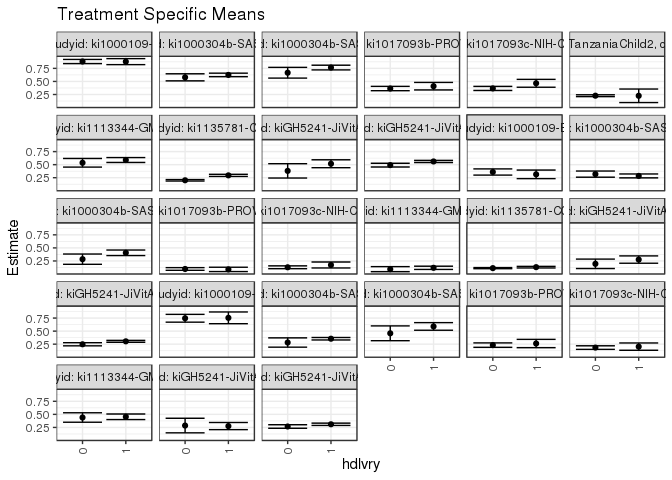

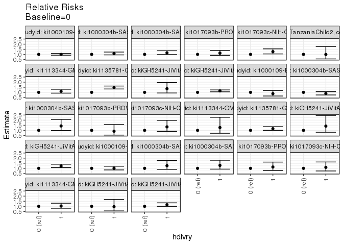

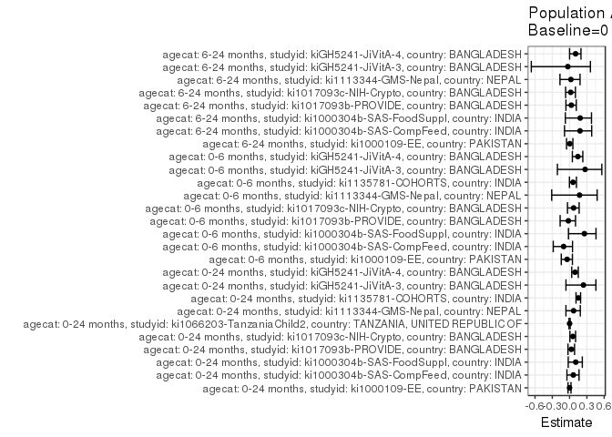

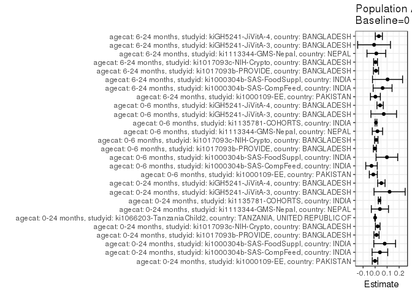

## Results Table

### Parameter: TSM

| agecat | studyid | country | intervention_level | baseline_level | estimate | ci_lower | ci_upper |
| --- | --- | --- | --- | --- | --- | --- | --- |
| 0-24 months | ki1000109-EE | PAKISTAN | 0 | NA | 0.8814229 | 0.8415336 | 0.9213123 |
| 0-24 months | ki1000109-EE | PAKISTAN | 1 | NA | 0.8790323 | 0.8215609 | 0.9365036 |
| 0-24 months | ki1000304b-SAS-CompFeed | INDIA | 0 | NA | 0.5783133 | 0.5106121 | 0.6460144 |
| 0-24 months | ki1000304b-SAS-CompFeed | INDIA | 1 | NA | 0.6245387 | 0.5910646 | 0.6580129 |
| 0-24 months | ki1000304b-SAS-FoodSuppl | INDIA | 0 | NA | 0.6666667 | 0.5638841 | 0.7694492 |
| 0-24 months | ki1000304b-SAS-FoodSuppl | INDIA | 1 | NA | 0.7655786 | 0.7202944 | 0.8108628 |
| 0-24 months | ki1017093b-PROVIDE | BANGLADESH | 0 | NA | 0.3641618 | 0.3227337 | 0.4055900 |
| 0-24 months | ki1017093b-PROVIDE | BANGLADESH | 1 | NA | 0.4088398 | 0.3371680 | 0.4805116 |
| 0-24 months | ki1017093c-NIH-Crypto | BANGLADESH | 0 | NA | 0.3661017 | 0.3272044 | 0.4049990 |
| 0-24 months | ki1017093c-NIH-Crypto | BANGLADESH | 1 | NA | 0.4642857 | 0.3888218 | 0.5397496 |
| 0-24 months | ki1066203-TanzaniaChild2 | TANZANIA, UNITED REPUBLIC OF | 0 | NA | 0.2269472 | 0.2095744 | 0.2443199 |
| 0-24 months | ki1066203-TanzaniaChild2 | TANZANIA, UNITED REPUBLIC OF | 1 | NA | 0.2250000 | 0.0955638 | 0.3544362 |
| 0-24 months | ki1113344-GMS-Nepal | NEPAL | 0 | NA | 0.5357143 | 0.4530285 | 0.6184001 |
| 0-24 months | ki1113344-GMS-Nepal | NEPAL | 1 | NA | 0.5890736 | 0.5420343 | 0.6361130 |
| 0-24 months | ki1135781-COHORTS | INDIA | 0 | NA | 0.2010178 | 0.1870079 | 0.2150277 |
| 0-24 months | ki1135781-COHORTS | INDIA | 1 | NA | 0.2951407 | 0.2749206 | 0.3153608 |
| 0-24 months | kiGH5241-JiVitA-3 | BANGLADESH | 0 | NA | 0.3809524 | 0.2436755 | 0.5182293 |
| 0-24 months | kiGH5241-JiVitA-3 | BANGLADESH | 1 | NA | 0.5176849 | 0.4420873 | 0.5932824 |
| 0-24 months | kiGH5241-JiVitA-4 | BANGLADESH | 0 | NA | 0.4910333 | 0.4553742 | 0.5266924 |
| 0-24 months | kiGH5241-JiVitA-4 | BANGLADESH | 1 | NA | 0.5612613 | 0.5407614 | 0.5817612 |
| 0-6 months | ki1000109-EE | PAKISTAN | 0 | NA | 0.3596838 | 0.3004701 | 0.4188975 |
| 0-6 months | ki1000109-EE | PAKISTAN | 1 | NA | 0.3145161 | 0.2326821 | 0.3963502 |
| 0-6 months | ki1000304b-SAS-CompFeed | INDIA | 0 | NA | 0.3192771 | 0.2601325 | 0.3784217 |
| 0-6 months | ki1000304b-SAS-CompFeed | INDIA | 1 | NA | 0.2846580 | 0.2470410 | 0.3222751 |
| 0-6 months | ki1000304b-SAS-FoodSuppl | INDIA | 0 | NA | 0.2839506 | 0.1856353 | 0.3822659 |
| 0-6 months | ki1000304b-SAS-FoodSuppl | INDIA | 1 | NA | 0.4059701 | 0.3533200 | 0.4586203 |
| 0-6 months | ki1017093b-PROVIDE | BANGLADESH | 0 | NA | 0.0963391 | 0.0709365 | 0.1217418 |
| 0-6 months | ki1017093b-PROVIDE | BANGLADESH | 1 | NA | 0.0883978 | 0.0470128 | 0.1297828 |
| 0-6 months | ki1017093c-NIH-Crypto | BANGLADESH | 0 | NA | 0.1288136 | 0.1017649 | 0.1558622 |
| 0-6 months | ki1017093c-NIH-Crypto | BANGLADESH | 1 | NA | 0.1726190 | 0.1154347 | 0.2298034 |
| 0-6 months | ki1113344-GMS-Nepal | NEPAL | 0 | NA | 0.0928571 | 0.0447381 | 0.1409762 |
| 0-6 months | ki1113344-GMS-Nepal | NEPAL | 1 | NA | 0.1187648 | 0.0878345 | 0.1496952 |
| 0-6 months | ki1135781-COHORTS | INDIA | 0 | NA | 0.1125286 | 0.1013251 | 0.1237321 |
| 0-6 months | ki1135781-COHORTS | INDIA | 1 | NA | 0.1312336 | 0.1160694 | 0.1463978 |
| 0-6 months | kiGH5241-JiVitA-3 | BANGLADESH | 0 | NA | 0.1951220 | 0.1047691 | 0.2854748 |
| 0-6 months | kiGH5241-JiVitA-3 | BANGLADESH | 1 | NA | 0.2765273 | 0.2060273 | 0.3470273 |
| 0-6 months | kiGH5241-JiVitA-4 | BANGLADESH | 0 | NA | 0.2482877 | 0.2181615 | 0.2784138 |
| 0-6 months | kiGH5241-JiVitA-4 | BANGLADESH | 1 | NA | 0.3046098 | 0.2865867 | 0.3226330 |
| 6-24 months | ki1000109-EE | PAKISTAN | 0 | NA | 0.7461538 | 0.6711402 | 0.8211675 |
| 6-24 months | ki1000109-EE | PAKISTAN | 1 | NA | 0.7543860 | 0.6423394 | 0.8664325 |
| 6-24 months | ki1000304b-SAS-CompFeed | INDIA | 0 | NA | 0.2818182 | 0.1927648 | 0.3708715 |
| 6-24 months | ki1000304b-SAS-CompFeed | INDIA | 1 | NA | 0.3545455 | 0.3311494 | 0.3779415 |
| 6-24 months | ki1000304b-SAS-FoodSuppl | INDIA | 0 | NA | 0.4583333 | 0.3170642 | 0.5996024 |
| 6-24 months | ki1000304b-SAS-FoodSuppl | INDIA | 1 | NA | 0.5898876 | 0.5174712 | 0.6623041 |
| 6-24 months | ki1017093b-PROVIDE | BANGLADESH | 0 | NA | 0.2321900 | 0.1896385 | 0.2747414 |
| 6-24 months | ki1017093b-PROVIDE | BANGLADESH | 1 | NA | 0.2627119 | 0.1832236 | 0.3422001 |
| 6-24 months | ki1017093c-NIH-Crypto | BANGLADESH | 0 | NA | 0.1849593 | 0.1506238 | 0.2192949 |
| 6-24 months | ki1017093c-NIH-Crypto | BANGLADESH | 1 | NA | 0.2031250 | 0.1333708 | 0.2728792 |
| 6-24 months | ki1113344-GMS-Nepal | NEPAL | 0 | NA | 0.4396552 | 0.3492305 | 0.5300799 |
| 6-24 months | ki1113344-GMS-Nepal | NEPAL | 1 | NA | 0.4534535 | 0.3999243 | 0.5069826 |
| 6-24 months | kiGH5241-JiVitA-3 | BANGLADESH | 0 | NA | 0.2857143 | 0.1463426 | 0.4250860 |
| 6-24 months | kiGH5241-JiVitA-3 | BANGLADESH | 1 | NA | 0.2758621 | 0.2072349 | 0.3444892 |
| 6-24 months | kiGH5241-JiVitA-4 | BANGLADESH | 0 | NA | 0.2674180 | 0.2336542 | 0.3011819 |
| 6-24 months | kiGH5241-JiVitA-4 | BANGLADESH | 1 | NA | 0.3102119 | 0.2882688 | 0.3321551 |

### Parameter: E(Y)

| agecat | studyid | country | intervention_level | baseline_level | estimate | ci_lower | ci_upper |
| --- | --- | --- | --- | --- | --- | --- | --- |
| 0-24 months | ki1000109-EE | PAKISTAN | NA | NA | 0.8806366 | 0.8478657 | 0.9134075 |
| 0-24 months | ki1000304b-SAS-CompFeed | INDIA | NA | NA | 0.6184000 | 0.5869018 | 0.6498982 |
| 0-24 months | ki1000304b-SAS-FoodSuppl | INDIA | NA | NA | 0.7464115 | 0.7046540 | 0.7881689 |
| 0-24 months | ki1017093b-PROVIDE | BANGLADESH | NA | NA | 0.3757143 | 0.3398113 | 0.4116172 |
| 0-24 months | ki1017093c-NIH-Crypto | BANGLADESH | NA | NA | 0.3878628 | 0.3531521 | 0.4225735 |
| 0-24 months | ki1066203-TanzaniaChild2 | TANZANIA, UNITED REPUBLIC OF | NA | NA | 0.2269129 | 0.2096946 | 0.2441313 |
| 0-24 months | ki1113344-GMS-Nepal | NEPAL | NA | NA | 0.5757576 | 0.5348239 | 0.6166913 |
| 0-24 months | ki1135781-COHORTS | INDIA | NA | NA | 0.2371053 | 0.2254305 | 0.2487802 |
| 0-24 months | kiGH5241-JiVitA-3 | BANGLADESH | NA | NA | 0.5014164 | 0.4307597 | 0.5720732 |
| 0-24 months | kiGH5241-JiVitA-4 | BANGLADESH | NA | NA | 0.5429904 | 0.5252738 | 0.5607071 |
| 0-6 months | ki1000109-EE | PAKISTAN | NA | NA | 0.3448276 | 0.2967843 | 0.3928709 |
| 0-6 months | ki1000304b-SAS-CompFeed | INDIA | NA | NA | 0.2892628 | 0.2523312 | 0.3261944 |
| 0-6 months | ki1000304b-SAS-FoodSuppl | INDIA | NA | NA | 0.3822115 | 0.3354600 | 0.4289631 |
| 0-6 months | ki1017093b-PROVIDE | BANGLADESH | NA | NA | 0.0942857 | 0.0726222 | 0.1159492 |
| 0-6 months | ki1017093c-NIH-Crypto | BANGLADESH | NA | NA | 0.1385224 | 0.1139141 | 0.1631308 |
| 0-6 months | ki1113344-GMS-Nepal | NEPAL | NA | NA | 0.1122995 | 0.0861492 | 0.1384497 |
| 0-6 months | ki1135781-COHORTS | INDIA | NA | NA | 0.1197098 | 0.1106766 | 0.1287430 |
| 0-6 months | kiGH5241-JiVitA-3 | BANGLADESH | NA | NA | 0.2670455 | 0.2046982 | 0.3293927 |
| 0-6 months | kiGH5241-JiVitA-4 | BANGLADESH | NA | NA | 0.2899487 | 0.2745556 | 0.3053419 |
| 6-24 months | ki1000109-EE | PAKISTAN | NA | NA | 0.7486631 | 0.6863237 | 0.8110026 |
| 6-24 months | ki1000304b-SAS-CompFeed | INDIA | NA | NA | 0.3441558 | 0.3190986 | 0.3692131 |
| 6-24 months | ki1000304b-SAS-FoodSuppl | INDIA | NA | NA | 0.5619469 | 0.4971181 | 0.6267757 |
| 6-24 months | ki1017093b-PROVIDE | BANGLADESH | NA | NA | 0.2394366 | 0.2018814 | 0.2769918 |
| 6-24 months | ki1017093c-NIH-Crypto | BANGLADESH | NA | NA | 0.1887097 | 0.1578857 | 0.2195336 |
| 6-24 months | ki1113344-GMS-Nepal | NEPAL | NA | NA | 0.4498886 | 0.4038220 | 0.4959553 |
| 6-24 months | kiGH5241-JiVitA-3 | BANGLADESH | NA | NA | 0.2771536 | 0.2152294 | 0.3390778 |
| 6-24 months | kiGH5241-JiVitA-4 | BANGLADESH | NA | NA | 0.2985158 | 0.2801281 | 0.3169036 |

### Parameter: RR

| agecat | studyid | country | intervention_level | baseline_level | estimate | ci_lower | ci_upper |
| --- | --- | --- | --- | --- | --- | --- | --- |
| 0-24 months | ki1000109-EE | PAKISTAN | 0 | 0 | 1.0000000 | 1.0000000 | 1.000000 |
| 0-24 months | ki1000109-EE | PAKISTAN | 1 | 0 | 0.9972877 | 0.9210591 | 1.079825 |
| 0-24 months | ki1000304b-SAS-CompFeed | INDIA | 0 | 0 | 1.0000000 | 1.0000000 | 1.000000 |
| 0-24 months | ki1000304b-SAS-CompFeed | INDIA | 1 | 0 | 1.0799316 | 0.9491681 | 1.228710 |
| 0-24 months | ki1000304b-SAS-FoodSuppl | INDIA | 0 | 0 | 1.0000000 | 1.0000000 | 1.000000 |
| 0-24 months | ki1000304b-SAS-FoodSuppl | INDIA | 1 | 0 | 1.1483680 | 0.9735662 | 1.354555 |
| 0-24 months | ki1017093b-PROVIDE | BANGLADESH | 0 | 0 | 1.0000000 | 1.0000000 | 1.000000 |
| 0-24 months | ki1017093b-PROVIDE | BANGLADESH | 1 | 0 | 1.1226870 | 0.9109582 | 1.383627 |
| 0-24 months | ki1017093c-NIH-Crypto | BANGLADESH | 0 | 0 | 1.0000000 | 1.0000000 | 1.000000 |
| 0-24 months | ki1017093c-NIH-Crypto | BANGLADESH | 1 | 0 | 1.2681878 | 1.0443620 | 1.539984 |
| 0-24 months | ki1066203-TanzaniaChild2 | TANZANIA, UNITED REPUBLIC OF | 0 | 0 | 1.0000000 | 1.0000000 | 1.000000 |
| 0-24 months | ki1066203-TanzaniaChild2 | TANZANIA, UNITED REPUBLIC OF | 1 | 0 | 0.9914201 | 0.5549043 | 1.771321 |
| 0-24 months | ki1113344-GMS-Nepal | NEPAL | 0 | 0 | 1.0000000 | 1.0000000 | 1.000000 |
| 0-24 months | ki1113344-GMS-Nepal | NEPAL | 1 | 0 | 1.0996041 | 0.9241974 | 1.308302 |
| 0-24 months | ki1135781-COHORTS | INDIA | 0 | 0 | 1.0000000 | 1.0000000 | 1.000000 |
| 0-24 months | ki1135781-COHORTS | INDIA | 1 | 0 | 1.4682314 | 1.3315310 | 1.618966 |
| 0-24 months | kiGH5241-JiVitA-3 | BANGLADESH | 0 | 0 | 1.0000000 | 1.0000000 | 1.000000 |
| 0-24 months | kiGH5241-JiVitA-3 | BANGLADESH | 1 | 0 | 1.3589228 | 0.9376458 | 1.969477 |
| 0-24 months | kiGH5241-JiVitA-4 | BANGLADESH | 0 | 0 | 1.0000000 | 1.0000000 | 1.000000 |
| 0-24 months | kiGH5241-JiVitA-4 | BANGLADESH | 1 | 0 | 1.1430208 | 1.0532436 | 1.240450 |
| 0-6 months | ki1000109-EE | PAKISTAN | 0 | 0 | 1.0000000 | 1.0000000 | 1.000000 |
| 0-6 months | ki1000109-EE | PAKISTAN | 1 | 0 | 0.8744240 | 0.6426932 | 1.189708 |
| 0-6 months | ki1000304b-SAS-CompFeed | INDIA | 0 | 0 | 1.0000000 | 1.0000000 | 1.000000 |
| 0-6 months | ki1000304b-SAS-CompFeed | INDIA | 1 | 0 | 0.8915705 | 0.7454198 | 1.066376 |
| 0-6 months | ki1000304b-SAS-FoodSuppl | INDIA | 0 | 0 | 1.0000000 | 1.0000000 | 1.000000 |
| 0-6 months | ki1000304b-SAS-FoodSuppl | INDIA | 1 | 0 | 1.4297210 | 0.9878216 | 2.069303 |
| 0-6 months | ki1017093b-PROVIDE | BANGLADESH | 0 | 0 | 1.0000000 | 1.0000000 | 1.000000 |
| 0-6 months | ki1017093b-PROVIDE | BANGLADESH | 1 | 0 | 0.9175691 | 0.5361493 | 1.570333 |
| 0-6 months | ki1017093c-NIH-Crypto | BANGLADESH | 0 | 0 | 1.0000000 | 1.0000000 | 1.000000 |
| 0-6 months | ki1017093c-NIH-Crypto | BANGLADESH | 1 | 0 | 1.3400689 | 0.9052918 | 1.983653 |
| 0-6 months | ki1113344-GMS-Nepal | NEPAL | 0 | 0 | 1.0000000 | 1.0000000 | 1.000000 |
| 0-6 months | ki1113344-GMS-Nepal | NEPAL | 1 | 0 | 1.2790059 | 0.7161368 | 2.284279 |
| 0-6 months | ki1135781-COHORTS | INDIA | 0 | 0 | 1.0000000 | 1.0000000 | 1.000000 |
| 0-6 months | ki1135781-COHORTS | INDIA | 1 | 0 | 1.1662241 | 1.0012452 | 1.358387 |
| 0-6 months | kiGH5241-JiVitA-3 | BANGLADESH | 0 | 0 | 1.0000000 | 1.0000000 | 1.000000 |
| 0-6 months | kiGH5241-JiVitA-3 | BANGLADESH | 1 | 0 | 1.4172026 | 0.8153391 | 2.463347 |
| 0-6 months | kiGH5241-JiVitA-4 | BANGLADESH | 0 | 0 | 1.0000000 | 1.0000000 | 1.000000 |
| 0-6 months | kiGH5241-JiVitA-4 | BANGLADESH | 1 | 0 | 1.2268423 | 1.0707962 | 1.405629 |
| 6-24 months | ki1000109-EE | PAKISTAN | 0 | 0 | 1.0000000 | 1.0000000 | 1.000000 |
| 6-24 months | ki1000109-EE | PAKISTAN | 1 | 0 | 1.0110327 | 0.8450327 | 1.209642 |
| 6-24 months | ki1000304b-SAS-CompFeed | INDIA | 0 | 0 | 1.0000000 | 1.0000000 | 1.000000 |
| 6-24 months | ki1000304b-SAS-CompFeed | INDIA | 1 | 0 | 1.2580645 | 0.9027143 | 1.753297 |
| 6-24 months | ki1000304b-SAS-FoodSuppl | INDIA | 0 | 0 | 1.0000000 | 1.0000000 | 1.000000 |
| 6-24 months | ki1000304b-SAS-FoodSuppl | INDIA | 1 | 0 | 1.2870276 | 0.9236367 | 1.793389 |
| 6-24 months | ki1017093b-PROVIDE | BANGLADESH | 0 | 0 | 1.0000000 | 1.0000000 | 1.000000 |
| 6-24 months | ki1017093b-PROVIDE | BANGLADESH | 1 | 0 | 1.1314522 | 0.7943442 | 1.611624 |
| 6-24 months | ki1017093c-NIH-Crypto | BANGLADESH | 0 | 0 | 1.0000000 | 1.0000000 | 1.000000 |
| 6-24 months | ki1017093c-NIH-Crypto | BANGLADESH | 1 | 0 | 1.0982143 | 0.7432784 | 1.622642 |
| 6-24 months | ki1113344-GMS-Nepal | NEPAL | 0 | 0 | 1.0000000 | 1.0000000 | 1.000000 |
| 6-24 months | ki1113344-GMS-Nepal | NEPAL | 1 | 0 | 1.0313843 | 0.8136380 | 1.307404 |
| 6-24 months | kiGH5241-JiVitA-3 | BANGLADESH | 0 | 0 | 1.0000000 | 1.0000000 | 1.000000 |
| 6-24 months | kiGH5241-JiVitA-3 | BANGLADESH | 1 | 0 | 0.9655172 | 0.5551173 | 1.679327 |
| 6-24 months | kiGH5241-JiVitA-4 | BANGLADESH | 0 | 0 | 1.0000000 | 1.0000000 | 1.000000 |
| 6-24 months | kiGH5241-JiVitA-4 | BANGLADESH | 1 | 0 | 1.1600263 | 1.0028903 | 1.341783 |

### Parameter: PAR

| agecat | studyid | country | intervention_level | baseline_level | estimate | ci_lower | ci_upper |
| --- | --- | --- | --- | --- | --- | --- | --- |
| 0-24 months | ki1000109-EE | PAKISTAN | 0 | NA | -0.0007863 | -0.0237966 | 0.0222240 |
| 0-24 months | ki1000304b-SAS-CompFeed | INDIA | 0 | NA | 0.0400867 | -0.0250105 | 0.1051840 |
| 0-24 months | ki1000304b-SAS-FoodSuppl | INDIA | 0 | NA | 0.0797448 | -0.0108844 | 0.1703741 |
| 0-24 months | ki1017093b-PROVIDE | BANGLADESH | 0 | NA | 0.0115524 | -0.0099021 | 0.0330070 |
| 0-24 months | ki1017093c-NIH-Crypto | BANGLADESH | 0 | NA | 0.0217611 | 0.0027216 | 0.0408006 |
| 0-24 months | ki1066203-TanzaniaChild2 | TANZANIA, UNITED REPUBLIC OF | 0 | NA | -0.0000343 | -0.0023315 | 0.0022630 |
| 0-24 months | ki1113344-GMS-Nepal | NEPAL | 0 | NA | 0.0400433 | -0.0313719 | 0.1114585 |
| 0-24 months | ki1135781-COHORTS | INDIA | 0 | NA | 0.0360875 | 0.0265726 | 0.0456024 |
| 0-24 months | kiGH5241-JiVitA-3 | BANGLADESH | 0 | NA | 0.1204640 | -0.0091143 | 0.2500424 |
| 0-24 months | kiGH5241-JiVitA-4 | BANGLADESH | 0 | NA | 0.0519571 | 0.0212756 | 0.0826387 |
| 0-6 months | ki1000109-EE | PAKISTAN | 0 | NA | -0.0148562 | -0.0481489 | 0.0184365 |
| 0-6 months | ki1000304b-SAS-CompFeed | INDIA | 0 | NA | -0.0300143 | -0.0778716 | 0.0178431 |
| 0-6 months | ki1000304b-SAS-FoodSuppl | INDIA | 0 | NA | 0.0982609 | 0.0083305 | 0.1881913 |
| 0-6 months | ki1017093b-PROVIDE | BANGLADESH | 0 | NA | -0.0020534 | -0.0146121 | 0.0105053 |
| 0-6 months | ki1017093c-NIH-Crypto | BANGLADESH | 0 | NA | 0.0097089 | -0.0043713 | 0.0237891 |
| 0-6 months | ki1113344-GMS-Nepal | NEPAL | 0 | NA | 0.0194423 | -0.0234951 | 0.0623797 |
| 0-6 months | ki1135781-COHORTS | INDIA | 0 | NA | 0.0071812 | -0.0000616 | 0.0144239 |
| 0-6 months | kiGH5241-JiVitA-3 | BANGLADESH | 0 | NA | 0.0719235 | -0.0346467 | 0.1784937 |
| 0-6 months | kiGH5241-JiVitA-4 | BANGLADESH | 0 | NA | 0.0416611 | 0.0154862 | 0.0678359 |
| 6-24 months | ki1000109-EE | PAKISTAN | 0 | NA | 0.0025093 | -0.0385949 | 0.0436134 |
| 6-24 months | ki1000304b-SAS-CompFeed | INDIA | 0 | NA | 0.0623377 | -0.0163485 | 0.1410239 |
| 6-24 months | ki1000304b-SAS-FoodSuppl | INDIA | 0 | NA | 0.1036136 | -0.0216160 | 0.2288431 |
| 6-24 months | ki1017093b-PROVIDE | BANGLADESH | 0 | NA | 0.0072466 | -0.0141903 | 0.0286836 |
| 6-24 months | ki1017093c-NIH-Crypto | BANGLADESH | 0 | NA | 0.0037503 | -0.0123111 | 0.0198117 |
| 6-24 months | ki1113344-GMS-Nepal | NEPAL | 0 | NA | 0.0102335 | -0.0677016 | 0.0881685 |
| 6-24 months | kiGH5241-JiVitA-3 | BANGLADESH | 0 | NA | -0.0085607 | -0.1450295 | 0.1279080 |
| 6-24 months | kiGH5241-JiVitA-4 | BANGLADESH | 0 | NA | 0.0310978 | 0.0016246 | 0.0605710 |

### Parameter: PAF

| agecat | studyid | country | intervention_level | baseline_level | estimate | ci_lower | ci_upper |
| --- | --- | --- | --- | --- | --- | --- | --- |
| 0-24 months | ki1000109-EE | PAKISTAN | 0 | NA | -0.0008929 | -0.0273664 | 0.0248985 |
| 0-24 months | ki1000304b-SAS-CompFeed | INDIA | 0 | NA | 0.0648233 | -0.0460717 | 0.1639623 |
| 0-24 months | ki1000304b-SAS-FoodSuppl | INDIA | 0 | NA | 0.1068376 | -0.0239385 | 0.2209112 |
| 0-24 months | ki1017093b-PROVIDE | BANGLADESH | 0 | NA | 0.0307479 | -0.0280845 | 0.0862136 |
| 0-24 months | ki1017093c-NIH-Crypto | BANGLADESH | 0 | NA | 0.0561052 | 0.0056649 | 0.1039867 |
| 0-24 months | ki1066203-TanzaniaChild2 | TANZANIA, UNITED REPUBLIC OF | 0 | NA | -0.0001509 | -0.0103262 | 0.0099219 |
| 0-24 months | ki1113344-GMS-Nepal | NEPAL | 0 | NA | 0.0695489 | -0.0633073 | 0.1858051 |
| 0-24 months | ki1135781-COHORTS | INDIA | 0 | NA | 0.1522003 | 0.1114544 | 0.1910778 |
| 0-24 months | kiGH5241-JiVitA-3 | BANGLADESH | 0 | NA | 0.2402475 | -0.0630298 | 0.4570013 |
| 0-24 months | kiGH5241-JiVitA-4 | BANGLADESH | 0 | NA | 0.0956870 | 0.0372381 | 0.1505876 |
| 0-6 months | ki1000109-EE | PAKISTAN | 0 | NA | -0.0430830 | -0.1442614 | 0.0491489 |
| 0-6 months | ki1000304b-SAS-CompFeed | INDIA | 0 | NA | -0.1037613 | -0.2835427 | 0.0508388 |
| 0-6 months | ki1000304b-SAS-FoodSuppl | INDIA | 0 | NA | 0.2570852 | -0.0194967 | 0.4586325 |
| 0-6 months | ki1017093b-PROVIDE | BANGLADESH | 0 | NA | -0.0217785 | -0.1639642 | 0.1030384 |
| 0-6 months | ki1017093c-NIH-Crypto | BANGLADESH | 0 | NA | 0.0700888 | -0.0367225 | 0.1658956 |
| 0-6 months | ki1113344-GMS-Nepal | NEPAL | 0 | NA | 0.1731292 | -0.3103036 | 0.4782008 |
| 0-6 months | ki1135781-COHORTS | INDIA | 0 | NA | 0.0599882 | -0.0023696 | 0.1184666 |
| 0-6 months | kiGH5241-JiVitA-3 | BANGLADESH | 0 | NA | 0.2693306 | -0.2114217 | 0.5592965 |
| 0-6 months | kiGH5241-JiVitA-4 | BANGLADESH | 0 | NA | 0.1436843 | 0.0482745 | 0.2295293 |
| 6-24 months | ki1000109-EE | PAKISTAN | 0 | NA | 0.0033516 | -0.0530959 | 0.0567735 |
| 6-24 months | ki1000304b-SAS-CompFeed | INDIA | 0 | NA | 0.1811321 | -0.0879933 | 0.3836868 |
| 6-24 months | ki1000304b-SAS-FoodSuppl | INDIA | 0 | NA | 0.1843832 | -0.0733386 | 0.3802229 |
| 6-24 months | ki1017093b-PROVIDE | BANGLADESH | 0 | NA | 0.0302654 | -0.0634747 | 0.1157428 |
| 6-24 months | ki1017093c-NIH-Crypto | BANGLADESH | 0 | NA | 0.0198735 | -0.0690063 | 0.1013637 |
| 6-24 months | ki1113344-GMS-Nepal | NEPAL | 0 | NA | 0.0227467 | -0.1667992 | 0.1815009 |
| 6-24 months | kiGH5241-JiVitA-3 | BANGLADESH | 0 | NA | -0.0308880 | -0.6641395 | 0.3613936 |
| 6-24 months | kiGH5241-JiVitA-4 | BANGLADESH | 0 | NA | 0.1041747 | 0.0000047 | 0.1974932 |